# Lipidomics report

2021-03-17

## Summary plots

### Bar plots for lipid classes

These plots show log2 transformed mean values for each condition within each lipid subclass. The errorbars show the standard error of the mean.  
More information can be found in the other tabs in the report.

### PC

#### High abundance

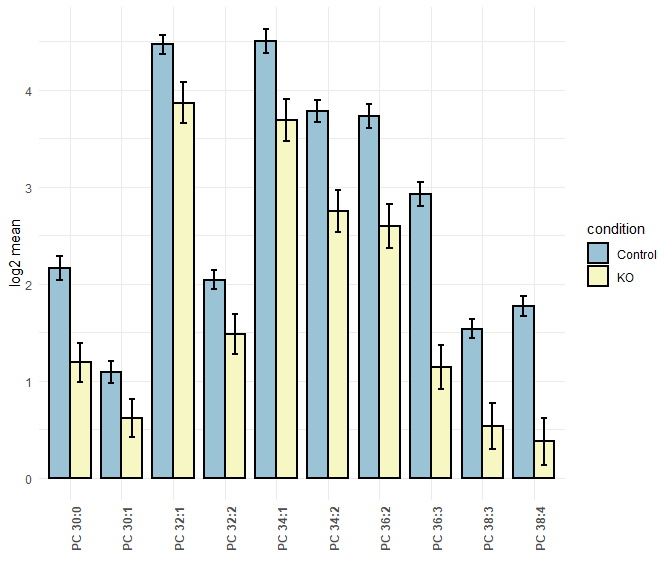

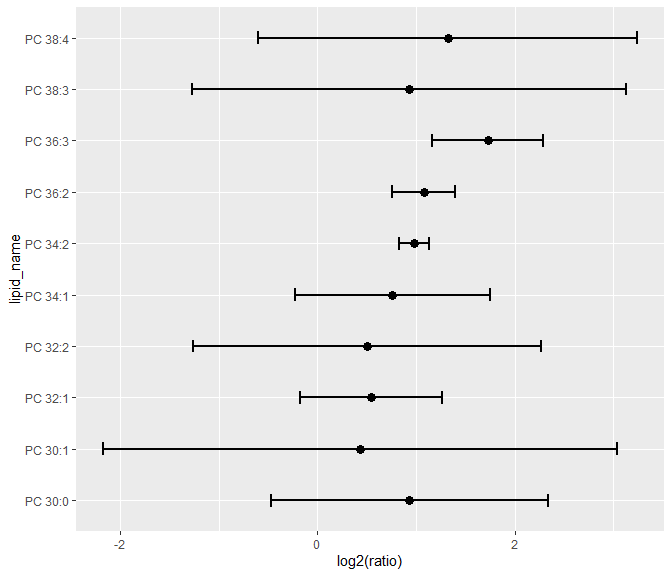

#### Low abundance log transformed

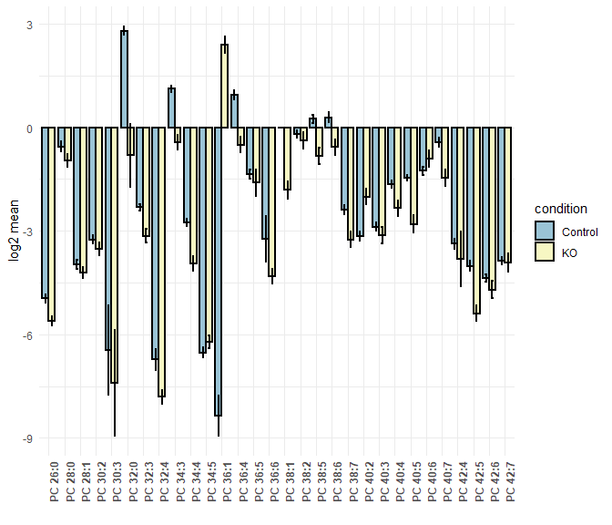

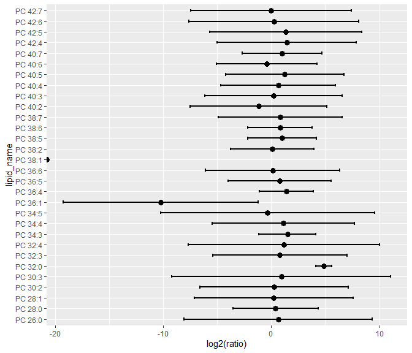

#### Low abundance linear

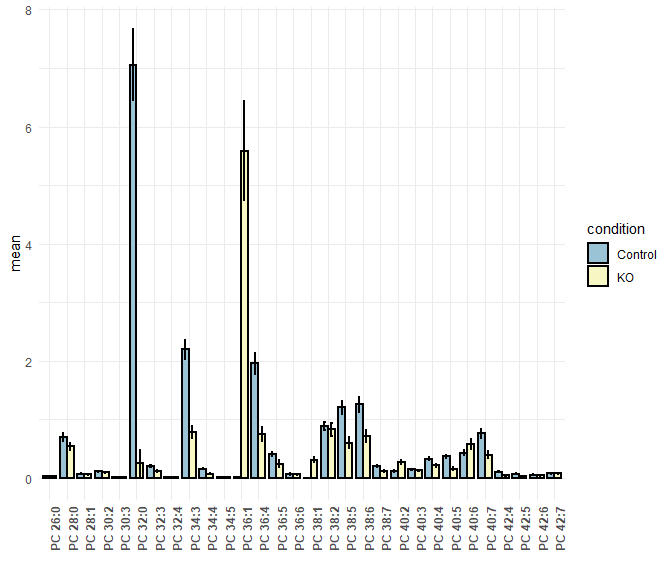

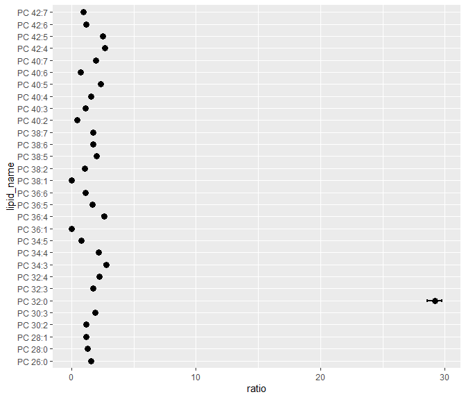

### SM

#### High abundance

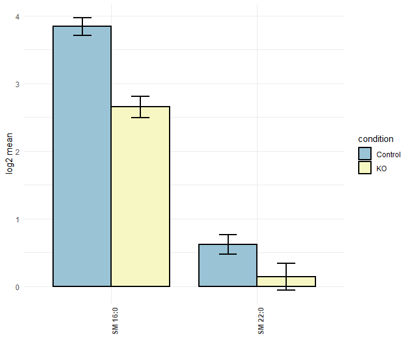

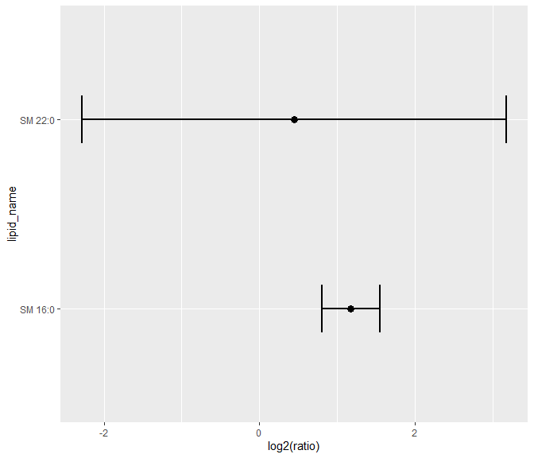

#### Low abundance log transformed

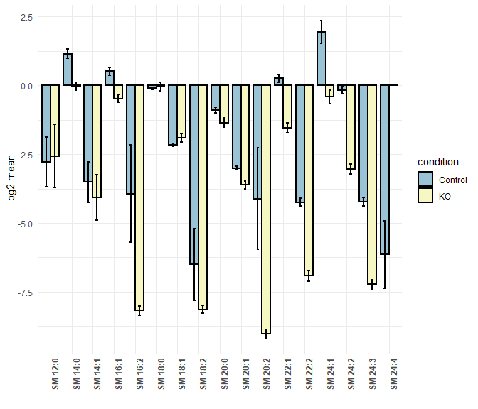

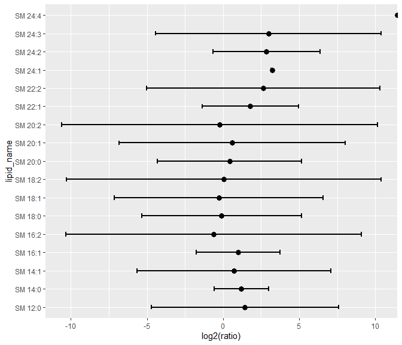

#### Low abundance linear

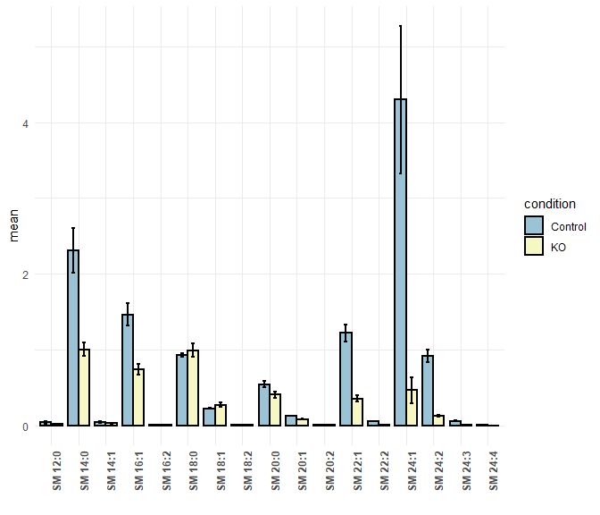

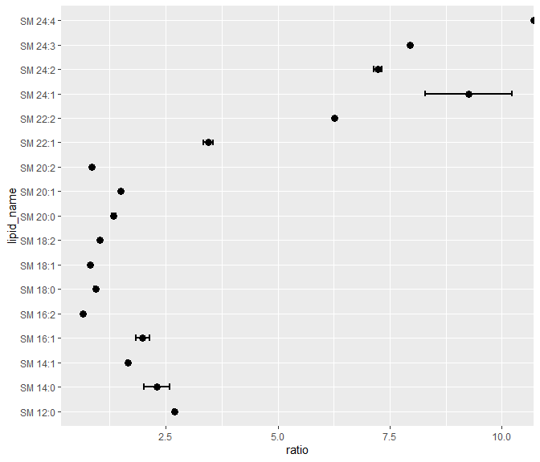

## Summary table

| class | lipid_name | fold_change | p_val | test_type | mean_Control | mean_KO | log2_fc |
| --- | --- | --- | --- | --- | --- | --- | --- |
| PC | PC 26:0 | 1.56661418946432 | 0.00987 | linear_paired_t_test | 0.0325293582319777 | 0.0207641156646874 | 0.647649930621728 |
| PC | PC 28:0 | 1.30886161263558 | 0.0793 | linear_paired_t_test | 0.696825378804586 | 0.532390416280473 | 0.388312567627958 |
| PC | PC 28:1 | 1.1636849733785 | 0.277 | linear_paired_t_test | 0.0651987119953057 | 0.0560278026156992 | 0.218700552355099 |
| PC | PC 30:0 | 1.906032006311 | 0.00217 | linear_paired_t_test | 4.54813117612846 | 2.38617775623352 | 0.93057234535408 |
| PC | PC 30:1 | 1.34921218374962 | 0.0388 | linear_paired_t_test | 2.16470504409286 | 1.60442150624292 | 0.432117251452511 |
| PC | PC 30:2 | 1.1888421393446 | 0.191 | linear_paired_t_test | 0.106630387909768 | 0.0896926382240723 | 0.249557159234458 |
| PC | PC 30:3 | 1.91972834520159 | 0.247 | linear_paired_t_test | 0.00399963462665707 | 0.00208343781382103 | 0.940902174093029 |
| PC | PC 32:0 | 29.1738088087115 |  | none | 7.05869269170417 | 0.241953072976759 | 4.86660184556382 |
| PC | PC 32:1 | 1.46090716574859 | 0.0217 | linear_paired_t_test | 22.3955167398023 | 15.3298698677588 | 0.546864504103477 |
| PC | PC 32:2 | 1.41845024418933 | 0.033 | linear_paired_t_test | 4.1571440346405 | 2.93076479183547 | 0.504315545240204 |

[output cut: 49 more lines]

## Metadata

| sample_name | condition |
| --- | --- |
| S1_1 | Control |
| S1_2 | Control |
| S1_3 | Control |
| S1_4 | Control |
| S1_5 | Control |
| S1_6 | Control |
| S2_1 | KO |
| S2_2 | KO |
| S2_3 | KO |
| S2_4 | KO |

[output cut: 2 more lines]

## Individual lipids

#### Scroll down to browse plots for individual lipids or click on the name in the table below to navigate directly to the plot.

| class | lipid_name | p_val | test_type | mean_Control | mean_KO | log2_fc |
| --- | --- | --- | --- | --- | --- | --- |
| PC | PC 26:0 | 0.00987 | linear_paired_t_test | 0.0325293582319777 | 0.0207641156646874 | 0.647649930621728 |
| PC | PC 28:0 | 0.0793 | linear_paired_t_test | 0.696825378804586 | 0.532390416280473 | 0.388312567627958 |
| PC | PC 28:1 | 0.277 | linear_paired_t_test | 0.0651987119953057 | 0.0560278026156992 | 0.218700552355099 |
| PC | PC 30:0 | 0.00217 | linear_paired_t_test | 4.54813117612846 | 2.38617775623352 | 0.93057234535408 |
| PC | PC 30:1 | 0.0388 | linear_paired_t_test | 2.16470504409286 | 1.60442150624292 | 0.432117251452511 |
| PC | PC 30:2 | 0.191 | linear_paired_t_test | 0.106630387909768 | 0.0896926382240723 | 0.249557159234458 |
| PC | PC 30:3 | 0.247 | linear_paired_t_test | 0.00399963462665707 | 0.00208343781382103 | 0.940902174093029 |
| PC | PC 32:0 |  | none | 7.05869269170417 | 0.241953072976759 | 4.86660184556382 |
| PC | PC 32:1 | 0.0217 | linear_paired_t_test | 22.3955167398023 | 15.3298698677588 | 0.546864504103477 |
| PC | PC 32:2 | 0.033 | linear_paired_t_test | 4.1571440346405 | 2.93076479183547 | 0.504315545240204 |

[output cut: 49 more lines]

### PC 26:0

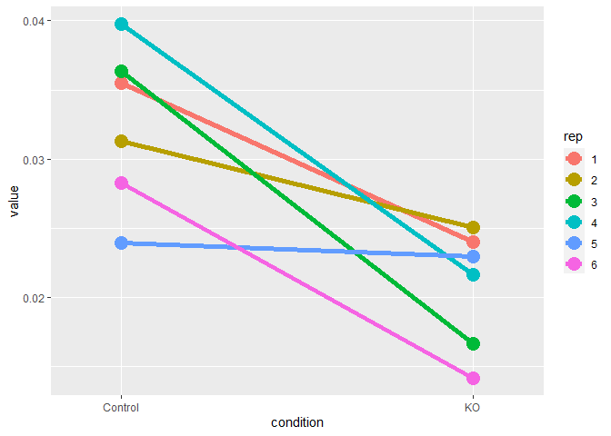

#### Test performed: linear_paired_t_test

#### p-value (uncorrected)

0.00987

Paired t-test performed on linear data. The ratio of standard deviations between the conditions was small enough that the data did not need to be log transformed. The samples were paired.

### PC 28:0

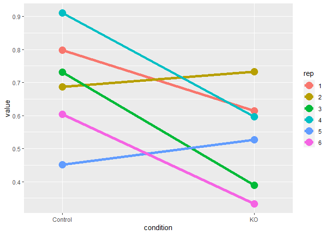

#### Test performed: linear_paired_t_test

#### p-value (uncorrected)

0.0793

Paired t-test performed on linear data. The ratio of standard deviations between the conditions was small enough that the data did not need to be log transformed. The samples were paired.

### PC 28:1

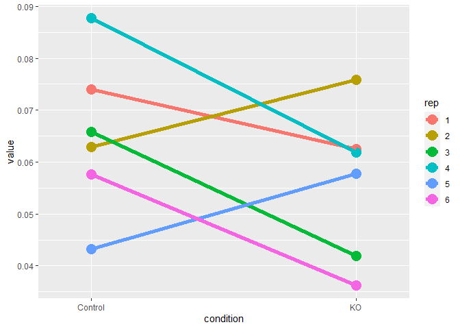

#### Test performed: linear_paired_t_test

#### p-value (uncorrected)

0.277

Paired t-test performed on linear data. The ratio of standard deviations between the conditions was small enough that the data did not need to be log transformed. The samples were paired.

### PC 30:0

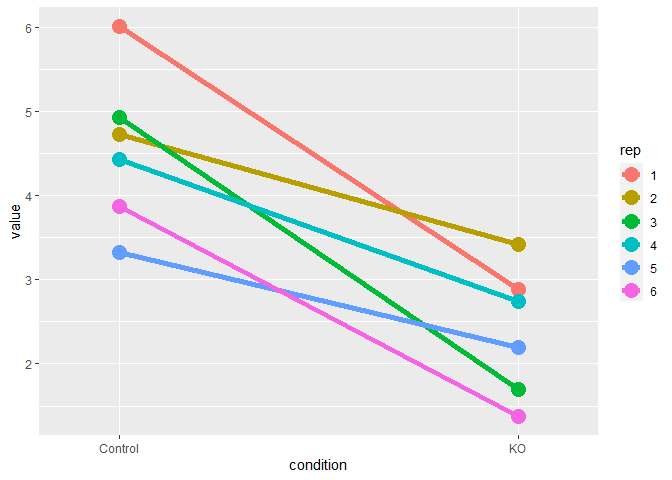

#### Test performed: linear_paired_t_test

#### p-value (uncorrected)

0.00217

Paired t-test performed on linear data. The ratio of standard deviations between the conditions was small enough that the data did not need to be log transformed. The samples were paired.

### PC 30:1

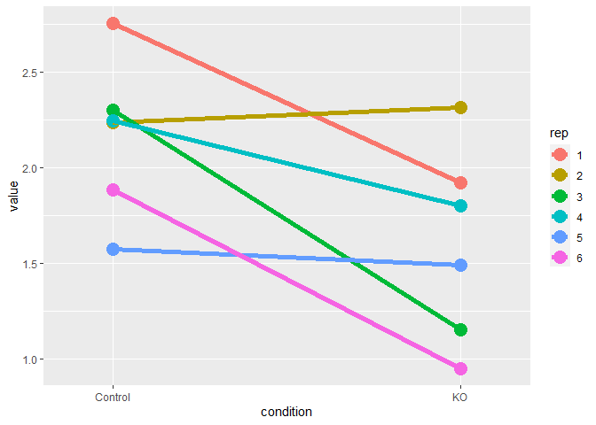

#### Test performed: linear_paired_t_test

#### p-value (uncorrected)

0.0388

Paired t-test performed on linear data. The ratio of standard deviations between the conditions was small enough that the data did not need to be log transformed. The samples were paired.

### PC 30:2

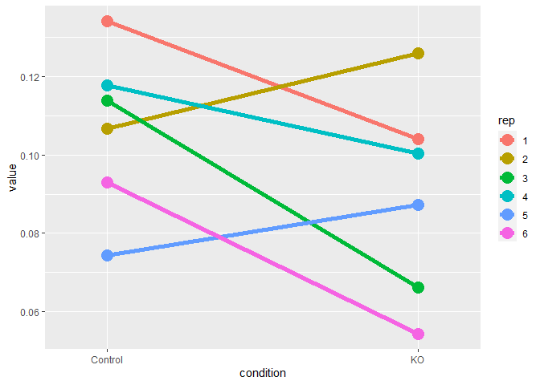

#### Test performed: linear_paired_t_test

#### p-value (uncorrected)

0.191

Paired t-test performed on linear data. The ratio of standard deviations between the conditions was small enough that the data did not need to be log transformed. The samples were paired.

### PC 30:3

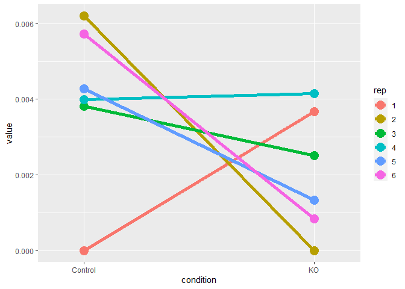

#### Test performed: linear_paired_t_test

#### p-value (uncorrected)

0.247

Paired t-test performed on linear data. The ratio of standard deviations between the conditions was small enough that the data did not need to be log transformed. The samples were paired.

### PC 32:0

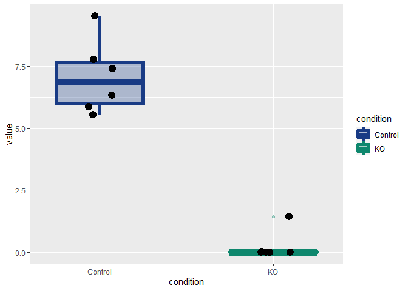

#### Test performed: none

#### p-value (uncorrected)

NA

The data did not meet the criteria for performing a statistical test. There may have been too few non-zero values or the variance of a condition may have been too high.

### PC 32:1

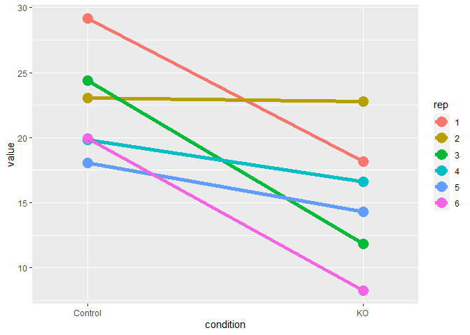

#### Test performed: linear_paired_t_test

#### p-value (uncorrected)

0.0217

Paired t-test performed on linear data. The ratio of standard deviations between the conditions was small enough that the data did not need to be log transformed. The samples were paired.

### PC 32:2

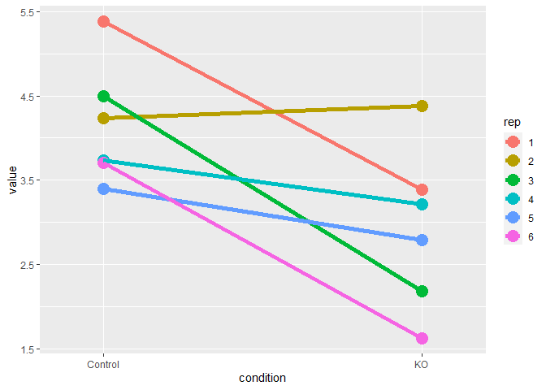

#### Test performed: linear_paired_t_test

#### p-value (uncorrected)

0.033

Paired t-test performed on linear data. The ratio of standard deviations between the conditions was small enough that the data did not need to be log transformed. The samples were paired.

### PC 32:3

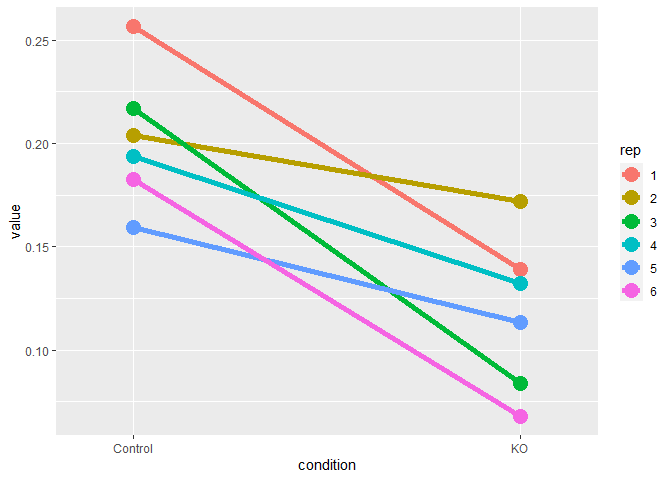

#### Test performed: linear_paired_t_test

#### p-value (uncorrected)

0.00477

Paired t-test performed on linear data. The ratio of standard deviations between the conditions was small enough that the data did not need to be log transformed. The samples were paired.

### PC 32:4

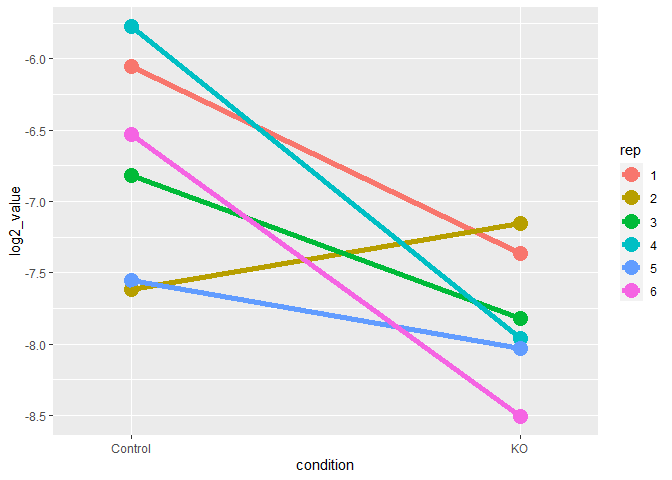

#### Test performed: log2_paired_t_test

#### p-value (uncorrected)

0.0429

Paired t-test performed on log2 transformed data. The ratio of standard deviations between the conditions exceeded a threshold and so the data was log2 transformed. The samples were paired.

### PC 34:1

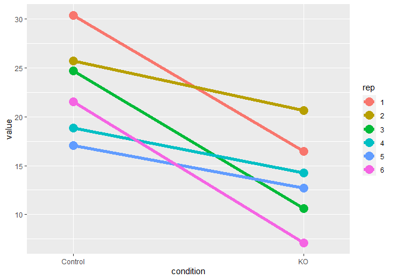

#### Test performed: linear_paired_t_test

#### p-value (uncorrected)

0.00671

Paired t-test performed on linear data. The ratio of standard deviations between the conditions was small enough that the data did not need to be log transformed. The samples were paired.

### PC 34:2

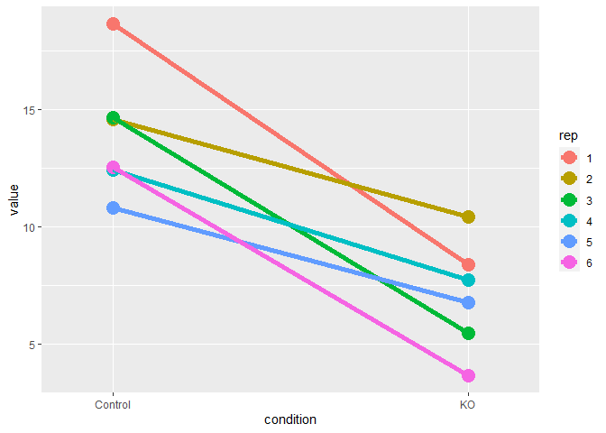

#### Test performed: linear_paired_t_test

#### p-value (uncorrected)

0.00202

Paired t-test performed on linear data. The ratio of standard deviations between the conditions was small enough that the data did not need to be log transformed. The samples were paired.

### PC 34:3

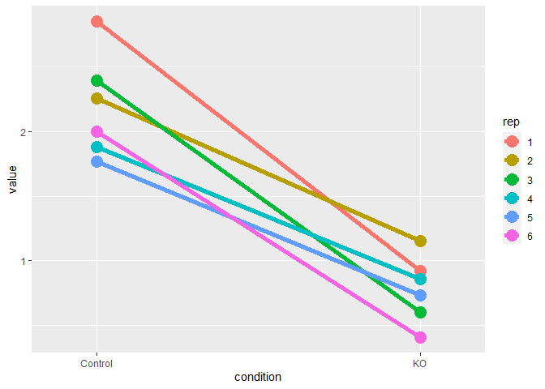

#### Test performed: linear_paired_t_test

#### p-value (uncorrected)

0.000375

Paired t-test performed on linear data. The ratio of standard deviations between the conditions was small enough that the data did not need to be log transformed. The samples were paired.

### PC 34:4

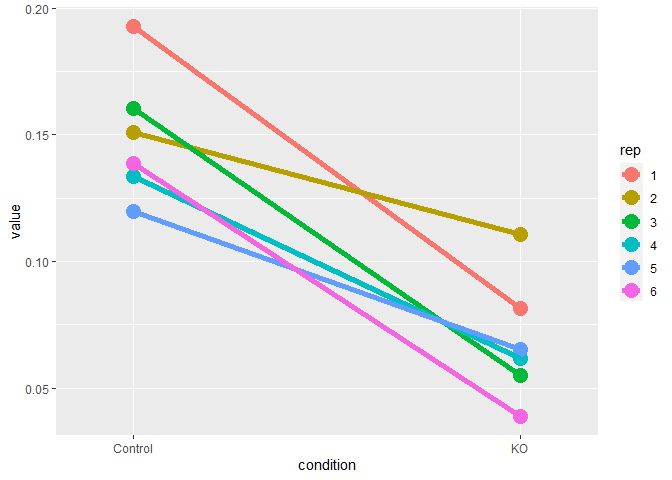

#### Test performed: linear_paired_t_test

#### p-value (uncorrected)

0.0011

Paired t-test performed on linear data. The ratio of standard deviations between the conditions was small enough that the data did not need to be log transformed. The samples were paired.

### PC 34:5

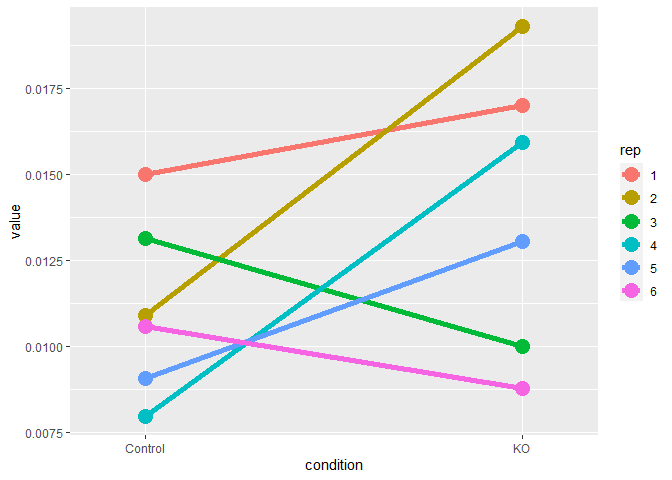

#### Test performed: linear_paired_t_test

#### p-value (uncorrected)

0.2

Paired t-test performed on linear data. The ratio of standard deviations between the conditions was small enough that the data did not need to be log transformed. The samples were paired.

### PC 36:1

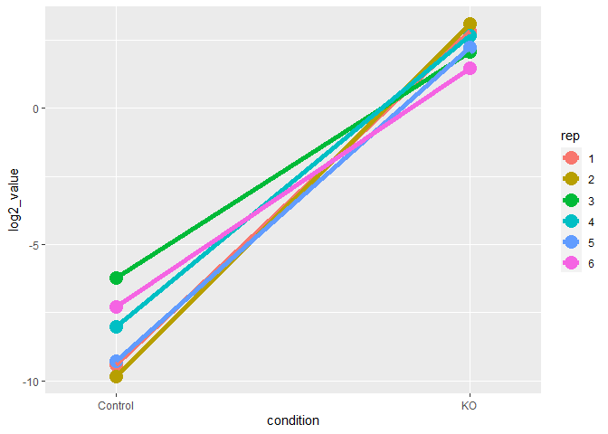

#### Test performed: log2_paired_t_test

#### p-value (uncorrected)

3.25e-05

Paired t-test performed on log2 transformed data. The ratio of standard deviations between the conditions exceeded a threshold and so the data was log2 transformed. The samples were paired.

### PC 36:2

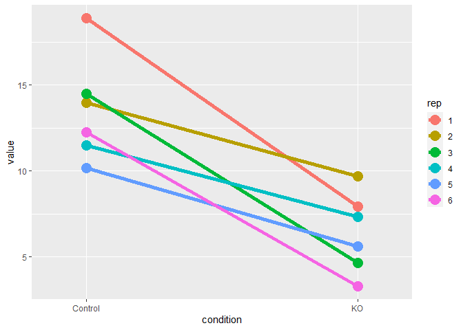

#### Test performed: linear_paired_t_test

#### p-value (uncorrected)

0.00253

Paired t-test performed on linear data. The ratio of standard deviations between the conditions was small enough that the data did not need to be log transformed. The samples were paired.

### PC 36:3

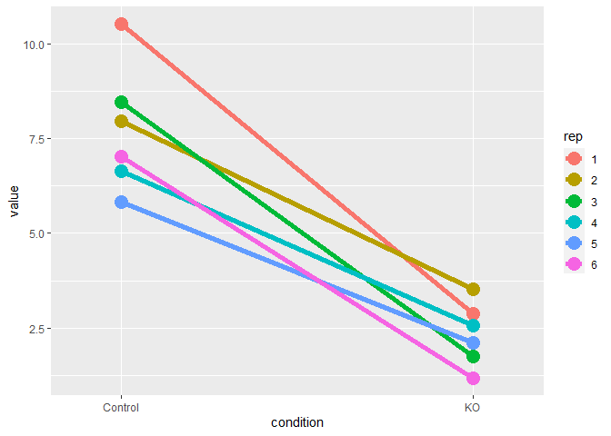

#### Test performed: linear_paired_t_test

#### p-value (uncorrected)

0.000399

Paired t-test performed on linear data. The ratio of standard deviations between the conditions was small enough that the data did not need to be log transformed. The samples were paired.

### PC 36:4

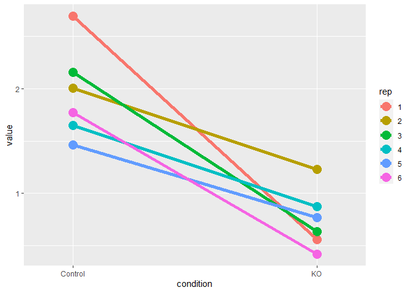

#### Test performed: linear_paired_t_test

#### p-value (uncorrected)

0.00346

Paired t-test performed on linear data. The ratio of standard deviations between the conditions was small enough that the data did not need to be log transformed. The samples were paired.

### PC 36:5

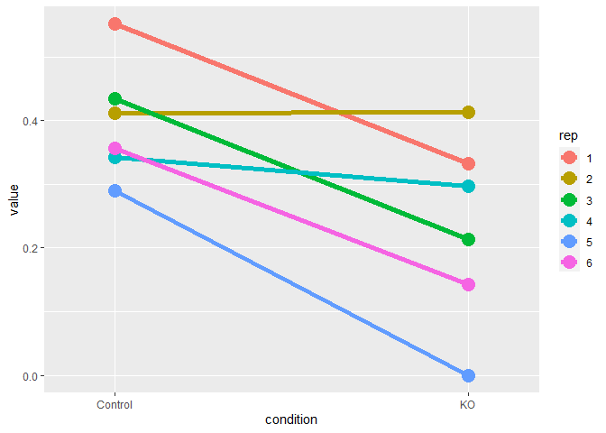

#### Test performed: linear_paired_t_test

#### p-value (uncorrected)

0.0171

Paired t-test performed on linear data. The ratio of standard deviations between the conditions was small enough that the data did not need to be log transformed. The samples were paired.

### PC 36:6

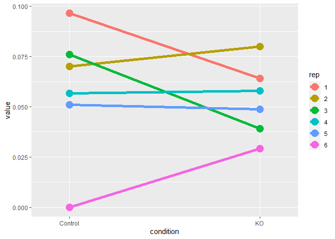

#### Test performed: linear_paired_t_test

#### p-value (uncorrected)

0.632

Paired t-test performed on linear data. The ratio of standard deviations between the conditions was small enough that the data did not need to be log transformed. The samples were paired.

### PC 38:1

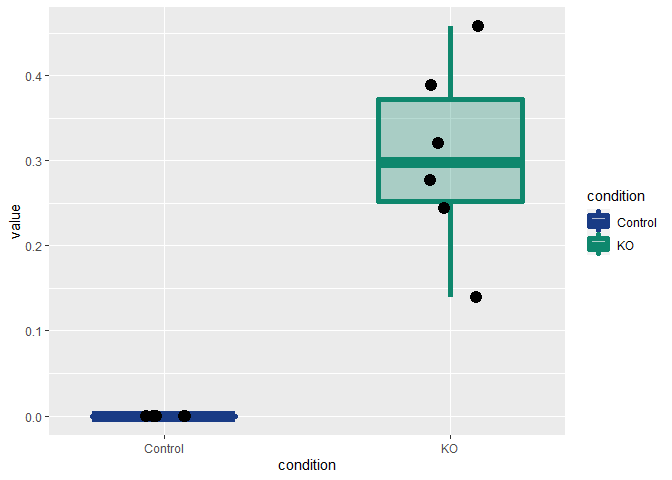

#### Test performed: none

#### p-value (uncorrected)

NA

The data did not meet the criteria for performing a statistical test. There may have been too few non-zero values or the variance of a condition may have been too high.

### PC 38:2

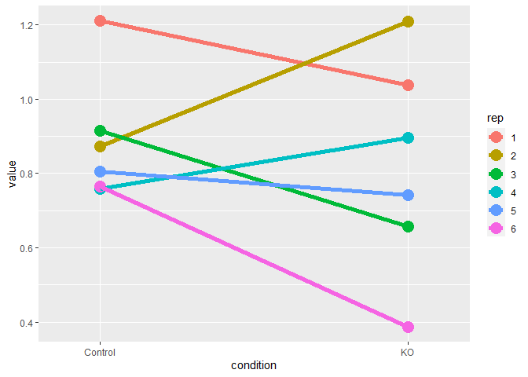

#### Test performed: linear_paired_t_test

#### p-value (uncorrected)

0.563

Paired t-test performed on linear data. The ratio of standard deviations between the conditions was small enough that the data did not need to be log transformed. The samples were paired.

### PC 38:3

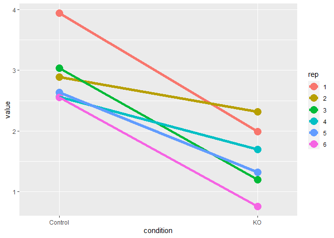

#### Test performed: linear_paired_t_test

#### p-value (uncorrected)

0.00191

Paired t-test performed on linear data. The ratio of standard deviations between the conditions was small enough that the data did not need to be log transformed. The samples were paired.

### PC 38:4

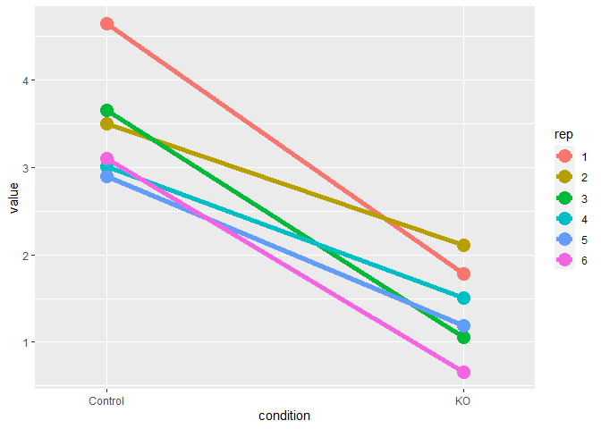

#### Test performed: linear_paired_t_test

#### p-value (uncorrected)

0.000445

Paired t-test performed on linear data. The ratio of standard deviations between the conditions was small enough that the data did not need to be log transformed. The samples were paired.

### PC 38:5

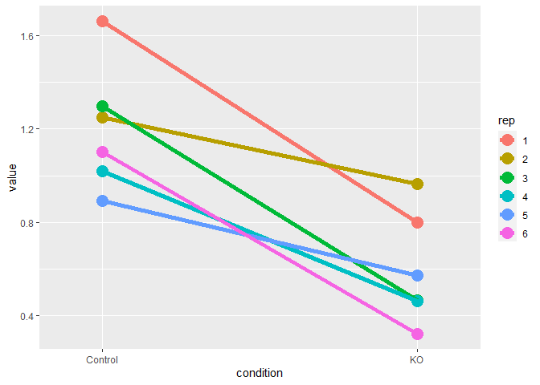

#### Test performed: linear_paired_t_test

#### p-value (uncorrected)

0.00224

Paired t-test performed on linear data. The ratio of standard deviations between the conditions was small enough that the data did not need to be log transformed. The samples were paired.

### PC 38:6

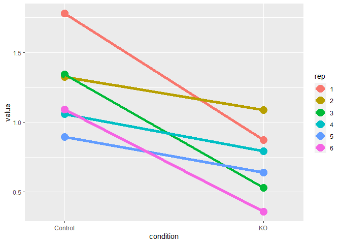

#### Test performed: linear_paired_t_test

#### p-value (uncorrected)

0.00865

Paired t-test performed on linear data. The ratio of standard deviations between the conditions was small enough that the data did not need to be log transformed. The samples were paired.

### PC 38:7

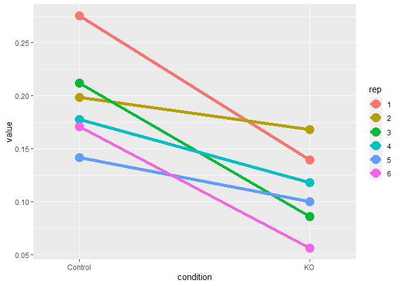

#### Test performed: linear_paired_t_test

#### p-value (uncorrected)

0.00637

Paired t-test performed on linear data. The ratio of standard deviations between the conditions was small enough that the data did not need to be log transformed. The samples were paired.

### PC 40:2

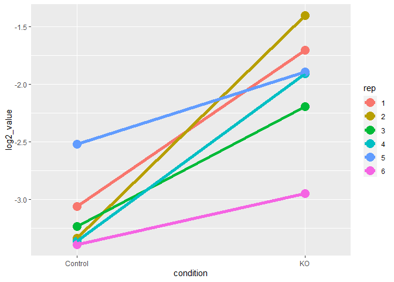

#### Test performed: log2_paired_t_test

#### p-value (uncorrected)

0.0039

Paired t-test performed on log2 transformed data. The ratio of standard deviations between the conditions exceeded a threshold and so the data was log2 transformed. The samples were paired.

### PC 40:3

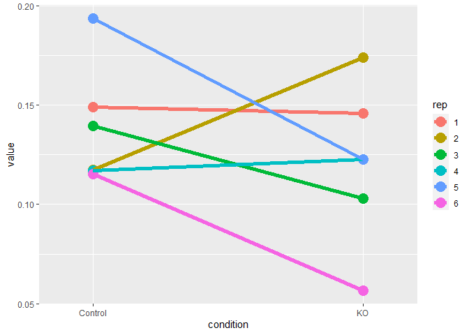

#### Test performed: linear_paired_t_test

#### p-value (uncorrected)

0.398

Paired t-test performed on linear data. The ratio of standard deviations between the conditions was small enough that the data did not need to be log transformed. The samples were paired.

### PC 40:4

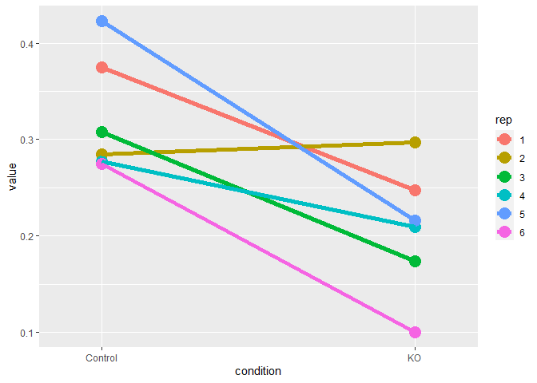

#### Test performed: linear_paired_t_test

#### p-value (uncorrected)

0.0152

Paired t-test performed on linear data. The ratio of standard deviations between the conditions was small enough that the data did not need to be log transformed. The samples were paired.

### PC 40:5

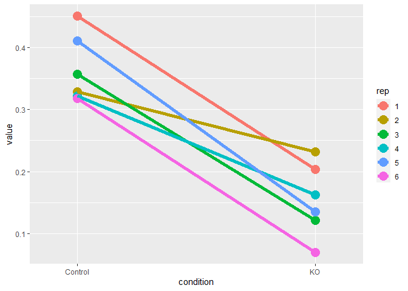

#### Test performed: linear_paired_t_test

#### p-value (uncorrected)

0.000622

Paired t-test performed on linear data. The ratio of standard deviations between the conditions was small enough that the data did not need to be log transformed. The samples were paired.

### PC 40:6

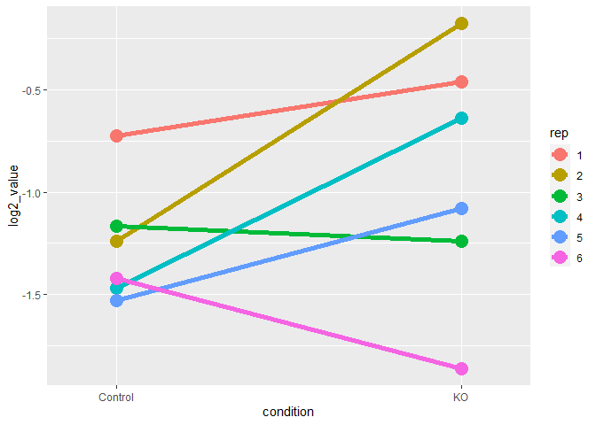

#### Test performed: log2_paired_t_test

#### p-value (uncorrected)

0.186

Paired t-test performed on log2 transformed data. The ratio of standard deviations between the conditions exceeded a threshold and so the data was log2 transformed. The samples were paired.

### PC 40:7

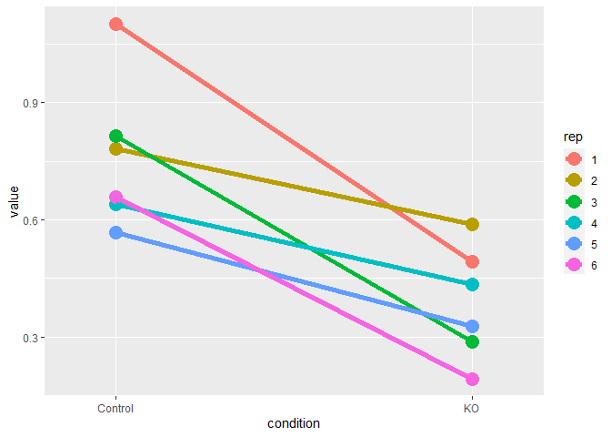

#### Test performed: linear_paired_t_test

#### p-value (uncorrected)

0.004

Paired t-test performed on linear data. The ratio of standard deviations between the conditions was small enough that the data did not need to be log transformed. The samples were paired.

### PC 42:4

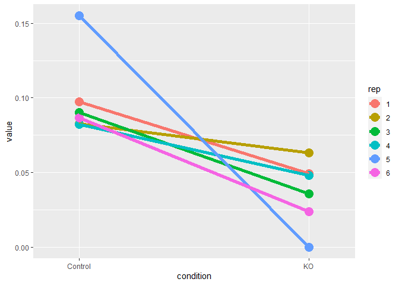

#### Test performed: linear_paired_t_test

#### p-value (uncorrected)

0.0242

Paired t-test performed on linear data. The ratio of standard deviations between the conditions was small enough that the data did not need to be log transformed. The samples were paired.

### PC 42:5

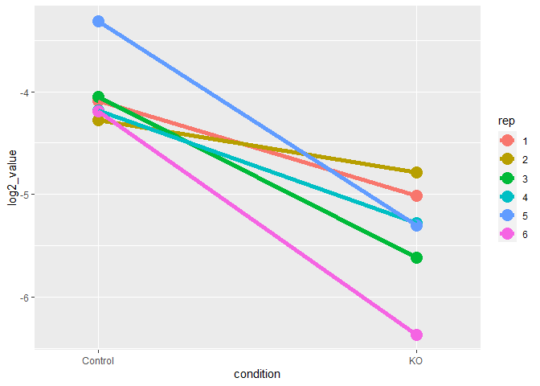

#### Test performed: log2_paired_t_test

#### p-value (uncorrected)

0.00342

Paired t-test performed on log2 transformed data. The ratio of standard deviations between the conditions exceeded a threshold and so the data was log2 transformed. The samples were paired.

### PC 42:6

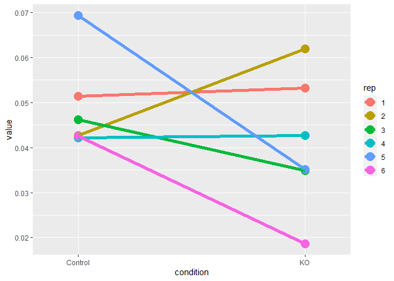

#### Test performed: linear_paired_t_test

#### p-value (uncorrected)

0.359

Paired t-test performed on linear data. The ratio of standard deviations between the conditions was small enough that the data did not need to be log transformed. The samples were paired.

### PC 42:7

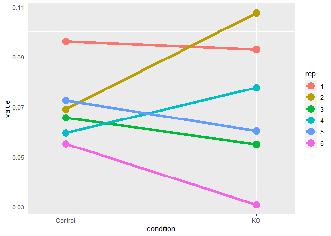

#### Test performed: linear_paired_t_test

#### p-value (uncorrected)

0.914

Paired t-test performed on linear data. The ratio of standard deviations between the conditions was small enough that the data did not need to be log transformed. The samples were paired.

### SM 12:0

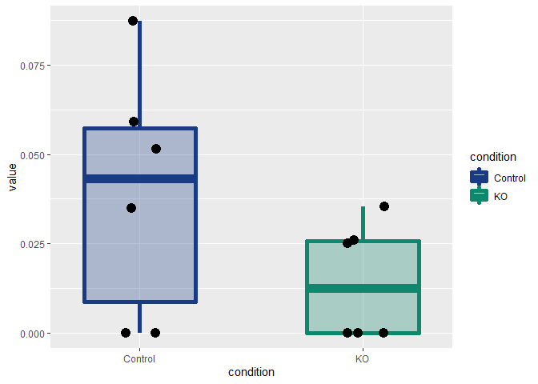

#### Test performed: none

#### p-value (uncorrected)

NA

The data did not meet the criteria for performing a statistical test. There may have been too few non-zero values or the variance of a condition may have been too high.

### SM 14:0

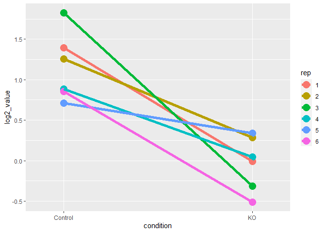

#### Test performed: log2_paired_t_test

#### p-value (uncorrected)

0.00492

Paired t-test performed on log2 transformed data. The ratio of standard deviations between the conditions exceeded a threshold and so the data was log2 transformed. The samples were paired.

### SM 14:1

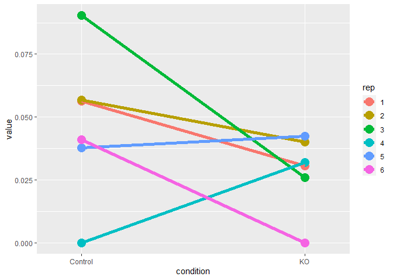

#### Test performed: linear_paired_t_test

#### p-value (uncorrected)

0.238

Paired t-test performed on linear data. The ratio of standard deviations between the conditions was small enough that the data did not need to be log transformed. The samples were paired.

### SM 16:0

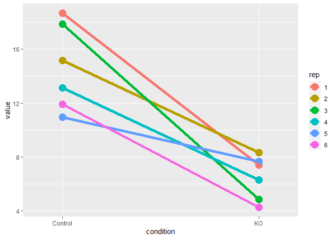

#### Test performed: linear_paired_t_test

#### p-value (uncorrected)

0.00223

Paired t-test performed on linear data. The ratio of standard deviations between the conditions was small enough that the data did not need to be log transformed. The samples were paired.

### SM 16:1

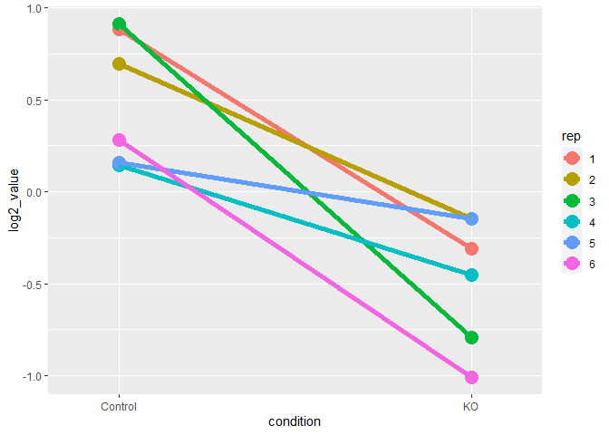

#### Test performed: log2_paired_t_test

#### p-value (uncorrected)

0.00503

Paired t-test performed on log2 transformed data. The ratio of standard deviations between the conditions exceeded a threshold and so the data was log2 transformed. The samples were paired.

### SM 16:2

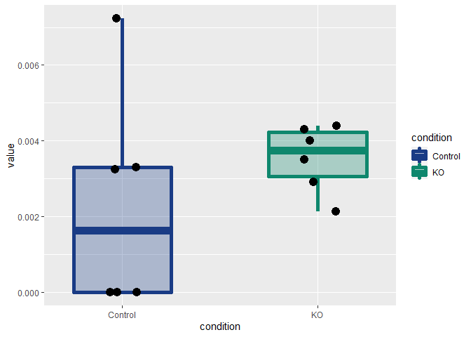

#### Test performed: none

#### p-value (uncorrected)

NA

The data did not meet the criteria for performing a statistical test. There may have been too few non-zero values or the variance of a condition may have been too high.

### SM 18:0

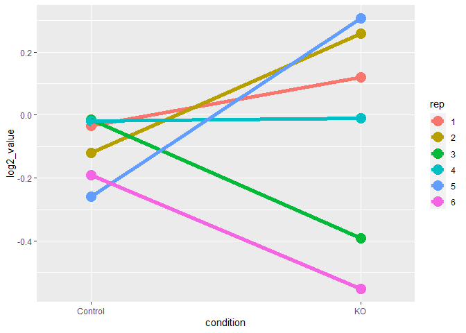

#### Test performed: log2_paired_t_test

#### p-value (uncorrected)

0.71

Paired t-test performed on log2 transformed data. The ratio of standard deviations between the conditions exceeded a threshold and so the data was log2 transformed. The samples were paired.

### SM 18:1

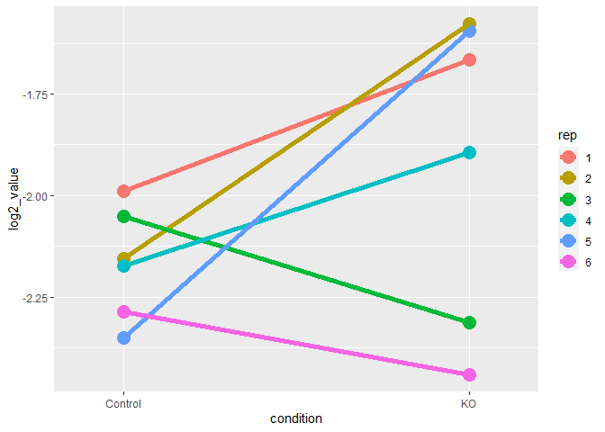

#### Test performed: log2_paired_t_test

#### p-value (uncorrected)

0.18

Paired t-test performed on log2 transformed data. The ratio of standard deviations between the conditions exceeded a threshold and so the data was log2 transformed. The samples were paired.

### SM 18:2

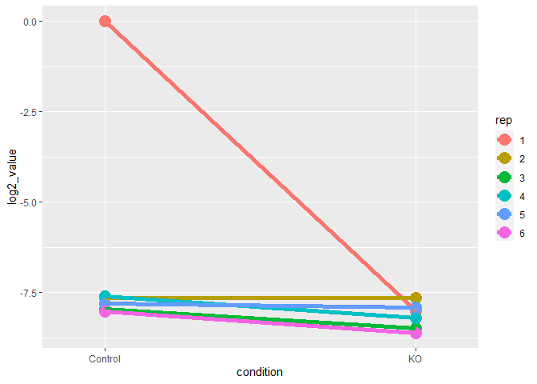

#### Test performed: log2_paired_t_test

#### p-value (uncorrected)

0.254

Paired t-test performed on log2 transformed data. The ratio of standard deviations between the conditions exceeded a threshold and so the data was log2 transformed. The samples were paired.

### SM 20:0

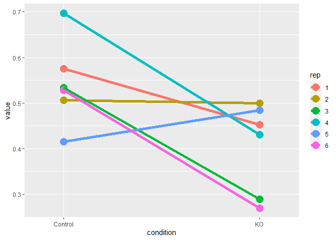

#### Test performed: linear_paired_t_test

#### p-value (uncorrected)

0.0647

Paired t-test performed on linear data. The ratio of standard deviations between the conditions was small enough that the data did not need to be log transformed. The samples were paired.

### SM 20:1

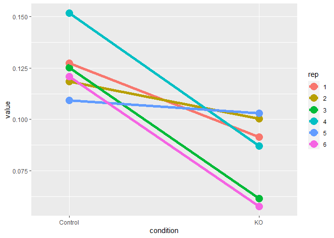

#### Test performed: linear_paired_t_test

#### p-value (uncorrected)

0.0103

Paired t-test performed on linear data. The ratio of standard deviations between the conditions was small enough that the data did not need to be log transformed. The samples were paired.